# Donor Data Stats

Kate Weaver

10/16/2021

## Load packages and dataframe

```r
library(ggplot2)
library(tidyverse)
library(here)
library(patchwork)
library(data.table)
load("bell_true_com_res_withInput.Rdata")
colnames(full_df)
```

```
## [1] "sample"      "sample_desc" "chr"         "num_snps"    "num_gametes"
## [6] "phase_com"   "imp_com"     "input_com"   "res"
```

```r
inf_df <- full_df[full_df$sample_desc == "inf",]
ninf_df <- full_df[full_df$sample_desc == "ninf",]
```

## Look at number of gametes

```r
donor_spec_gam <- lapply(1:length(unique(full_df$sample)), function(x) full_df$num_gametes[which(unique(full_df$sample)[x] == full_df$sample)]) %>% `names<-`(unique(full_df$sample))
donor_spec_gam
```

```
## $nc1abnov17
##  [1] 981 980 982 982 982 981 982 981 980 982 982 982 980 980 981 982 981 982 982
## [20] 982 979 981
##
## $nc2absept17
##  [1] 1677 1674 1674 1678 1678 1677 1679 1677 1666 1680 1680 1679 1679 1679 1678
## [16] 1678 1680 1679 1679 1679 1679 1679
##
## $nc3aboct17
##  [1] 1288 1287 1287 1286 1288 1289 1288 1288 1284 1289 1288 1288 1288 1288 1288
## [16] 1288 1288 1289 1287 1288 1288 1282
##
## $nc4abnov17
##  [1] 1479 1482 1482 1480 1480 1481 1481 1482 1481 1482 1482 1482 1482 1482 1482
## [16] 1479 1482 1481 1482 1482 1479 1479
##
## $nc6abcd
##  [1] 1365 1369 1370 1369 1370 1370 1370 1370 1368 1370 1370 1370 1369 1369 1370
## [16] 1370 1370 1370 1370 1370 1368 1366
##
## $nc8ab
##  [1] 1659 1663 1659 1659 1663 1662 1661 1663 1660 1660 1662 1663 1654 1659 1658
## [16] 1661 1663 1660 1662 1662 1656 1660
##
## $nc9ab
##  [1] 1888 1892 1894 1893 1892 1893 1892 1893 1892 1893 1894 1894 1893 1894 1892
## [16] 1894 1894 1894 1894 1894 1891 1892
##
## $nc10oldoil
##  [1] 1154 1151 1154 1153 1154 1153 1154 1154 1149 1153 1154 1152 1154 1153 1153
## [16] 1154 1154 1153 1153 1153 1149 1153
##
## $nc11ab
##  [1] 1927 1928 1928 1928 1930 1930 1928 1929 1927 1930 1930 1930 1926 1929 1925
## [16] 1928 1928 1929 1929 1928 1926 1928
##
## $nc12ab
##  [1] 2144 2143 2144 2143 2144 2145 2143 2144 2141 2145 2145 2144 2144 2142 2142
## [16] 2145 2144 2144 2145 2144 2141 2144
##
```

[output cut: 44 more lines]

```
## $ff4a
##  [1] 1410 1410 1410 1410 1410 1410 1410 1410 1410 1410 1410 1410 1410 1410 1410
## [16] 1410 1410 1410 1410 1410 1410 1410
##
## $pb2a
##  [1] 1523 1523 1521 1523 1523 1523 1523 1523 1523 1523 1523 1523 1523 1523 1523
## [16] 1523 1523 1523 1523 1523 1523 1523
##
## $pb3a
##  [1] 2289 2289 2289 2289 2289 2289 2289 2289 2289 2289 2289 2289 2289 2289 2289
## [16] 2289 2289 2289 2288 2289 2289 2288
##
## $pb4a
##  [1] 2421 2421 2421 2421 2421 2421 2421 2421 2421 2421 2421 2421 2421 2421 2421
## [16] 2421 2421 2421 2421 2421 2420 2420
```

```r
unlist(lapply(1:length(donor_spec_gam), function(x) length(unique(donor_spec_gam[[x]]))  == 1)) %>% `names<-`(names(donor_spec_gam))
```

```
##  nc1abnov17 nc2absept17  nc3aboct17  nc4abnov17     nc6abcd       nc8ab
##       FALSE       FALSE       FALSE       FALSE       FALSE       FALSE
##       nc9ab  nc10oldoil      nc11ab      nc12ab      nc13ab      nc14ab
##       FALSE       FALSE       FALSE       FALSE       FALSE       FALSE
##      nc15ab      nc16ab      nc17ab      nc18ab    nc22abcd    nc25abcd
##       FALSE       FALSE       FALSE       FALSE       FALSE       FALSE
##    nc26abcd nc27aboct17        ff3a        ff4a        pb2a        pb3a
##       FALSE       FALSE       FALSE        TRUE       FALSE       FALSE
##        pb4a
##       FALSE
```

Note that all donors but ff4a have differing numbers of gametes per chromosome. Could this be due to filtering to just euploid data?

To get the highest total number of gametes:

```r
max_donor <- unlist(lapply(1:length(donor_spec_gam), function(x) max(donor_spec_gam[[x]])))
max_donor
```

```
##  [1]  982 1680 1289 1482 1370 1663 1894 1154 1930 2145 1514 1336 1702 1785 1504
## [16] 1589 1693 2274  974 1268 3929 1410 1523 2289 2421
```

```r
highest_total <- sum(max_donor)
highest_total
```

```
## [1] 42800
```

```r
num_gams <- data.frame()
for (i in 1:22){
  num_gams <- rbind(num_gams, data.frame(chr=paste0("chr", i), num_cells=sum(unlist(lapply(1:length(names(donor_spec_gam)), function(x) donor_spec_gam[[x]][i])))))
}
num_gams
```

```
##      chr num_cells
## 1   chr1     42759
## 2   chr2     42757
## 3   chr3     42775
## 4   chr4     42770
## 5   chr5     42783
## 6   chr6     42788
## 7   chr7     42780
## 8   chr8     42782
## 9   chr9     42722
## 10 chr10     42787
## 11 chr11     42790
## 12 chr12     42791
## 13 chr13     42763
## 14 chr14     42768
## 15 chr15     42748
## 16 chr16     42773
## 17 chr17     42788
## 18 chr18     42783
## 19 chr19     42783
## 20 chr20     42783
## 21 chr21     42730
## 22 chr22     42741
```

Given the observation before this that gamete number isn’t constant across chromosomes for a given donor, here I’ve summed the number of gametes across the donors in a chromosome specific manner. chr9 has the minimum number of 42722 cells and chr12 has the maximum with 42791 cells. Note this is with pooling the infertile donors with the original set.

```r
mean(num_gams$num_cells)
```

```
## [1] 42770.18
```

### Infertile Donors

```r
min_inf_gam <- which(inf_df$num_gametes == min(inf_df$num_gametes))[1]
inf_df[min_inf_gam, c("sample", "chr", "num_gametes")]
```

```
##    sample chr num_gametes
## 22   ff4a   1        1410
```

```r
max_inf_gam <- which(inf_df$num_gametes == max(inf_df$num_gametes))[1]
inf_df[max_inf_gam, c("sample", 'chr', "num_gametes")]
```

```
##    sample chr num_gametes
## 21   ff3a   1        3929
```

```r
quant_inf <- quantile(inf_df$num_gametes)
quant_inf
```

```
##   0%  25%  50%  75% 100%
## 1410 1523 2289 2421 3929
```

### Original Cohort of Donors

```r
min_ninf_gam <- which(ninf_df$num_gametes == min(ninf_df$num_gametes))[1]
ninf_df[min_ninf_gam, c("sample",'chr', "num_gametes")]
```

```
##       sample chr num_gametes
## 544 nc26abcd  22         969
```

```r
max_ninf_gam <- which(ninf_df$num_gametes == max(ninf_df$num_gametes))[1]
ninf_df[max_ninf_gam, c("sample",'chr', "num_gametes")]
```

```
##      sample chr num_gametes
## 68 nc25abcd   3        2274
```

```r
quant_ninf <- quantile(ninf_df$num_gametes)
quant_ninf
```

```
##      0%     25%     50%     75%    100%
##  969.00 1319.75 1550.00 1721.50 2274.00
```

```r
quant_tot <- quantile(full_df$num_gametes)
quant_tot
```

```
##   0%  25%  50%  75% 100%
##  969 1369 1588 1894 3929
```

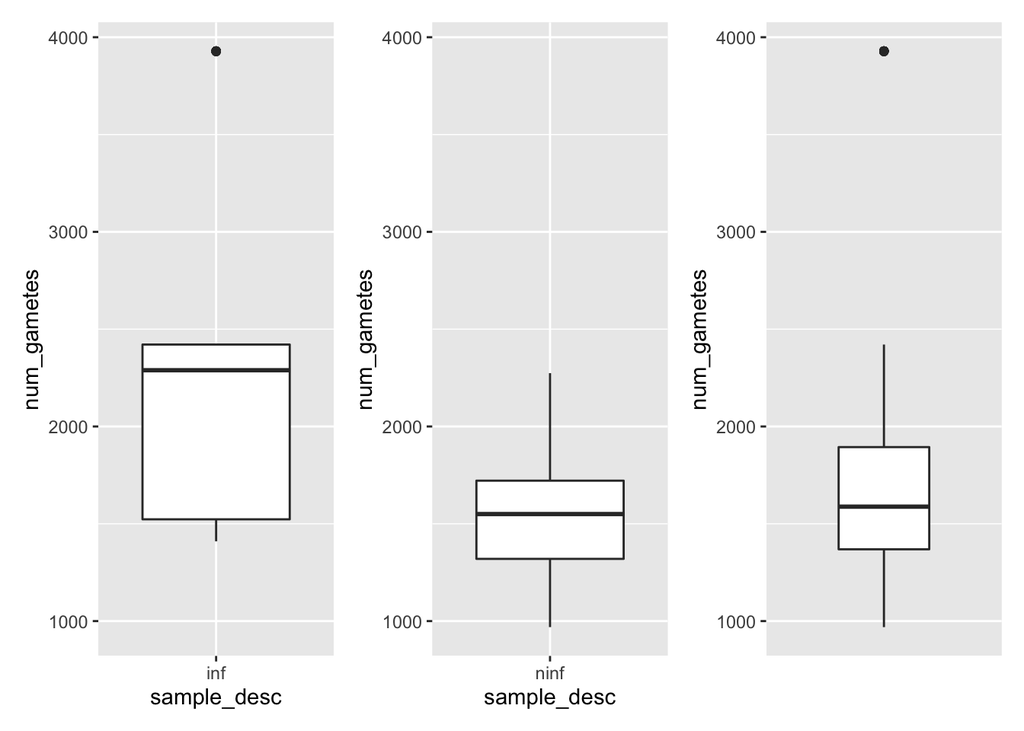

```r
g_inf <- ggplot(inf_df, aes(x = sample_desc, y = num_gametes)) + geom_boxplot() + scale_y_continuous(limits=c(min(ninf_df$num_gametes[min_ninf_gam], inf_df$num_gametes[min_inf_gam]), max(ninf_df$num_gametes[max_ninf_gam], inf_df$num_gametes[max_inf_gam])))
g_ninf <- ggplot(ninf_df, aes(x = sample_desc, y = num_gametes)) + geom_boxplot() + scale_y_continuous(limits=c(min(ninf_df$num_gametes[min_ninf_gam], inf_df$num_gametes[min_inf_gam]), max(ninf_df$num_gametes[max_ninf_gam], inf_df$num_gametes[max_inf_gam])))
g_tot <- ggplot(full_df, aes(y = num_gametes)) + geom_boxplot() + scale_y_continuous(limits=c(min(ninf_df$num_gametes[min_ninf_gam], inf_df$num_gametes[min_inf_gam]), max(ninf_df$num_gametes[max_ninf_gam], inf_df$num_gametes[max_inf_gam]))) + scale_x_discrete(labels=c("both"))

g <- g_inf + g_ninf + g_tot
g
```

In this plot of the number of gametes (donor and chromosome specific), the infertile donors are on the left, the original donor set is in the middle, the combined set is on the left.

```r
message(paste0("mean infertile donors: ", mean(inf_df$num_gametes)))
```

```
## mean infertile donors: 2314.25454545455
```

```r
message(paste0("sd infertile donors: ", sd(inf_df$num_gametes)))
```

```
## sd infertile donors: 905.44161698485
```

```r
message(paste0("mean original donors: ", mean(ninf_df$num_gametes)))
```

```
## mean original donors: 1559.94545454545
```

```r
message(paste0("sd original donors: ", sd(ninf_df$num_gametes)))
```

```
## sd original donors: 340.088427101077
```

```r
message(paste0('mean all: ', mean(full_df$num_gametes)))
```

```
## mean all: 1710.80727272727
```

```r
message(paste0("sd all: ", sd(full_df$num_gametes)))
```

```
## sd all: 588.60785955776
```

## Look at number of SNPs post filtering

```r
donor_spec_snp <- lapply(1:length(unique(full_df$sample)), function(x) full_df$num_snps[which(unique(full_df$sample)[x] == full_df$sample)]) %>% `names<-`(unique(full_df$sample))
donor_spec_snp
```

```
## $nc1abnov17
##  [1] 106435 123116 101925 101841  95017  85243  78799  80365  59270  70367
## [11]  67961  65507  49790  44489  38317  42833  33966  41510  26926  33390
## [21]  19314  16509
##
## $nc2absept17
##  [1] 111548 117802  99788 102536  91721  86757  76724  77109  60404  72386
## [11]  67644  64923  52595  43583  40373  43074  33172  38967  28024  33361
## [21]  19205  18821
##
## $nc3aboct17
##  [1] 109095 117054 103411  99468  85925  85258  79759  74330  59676  70568
## [11]  64069  61488  47412  44806  37407  44391  32602  39486  26266  32445
## [21]  18660  17733
##
## $nc4abnov17
##  [1] 106123 120404 105998 102968  88347  87473  79230  73698  57384  69624
## [11]  66241  70500  48977  47315  39837  43989  31503  39427  27079  33594
## [21]  19361  16469
##
## $nc6abcd
##  [1] 131131 142362 121216 118307 110024 102287  92831  93614  72108  84484
## [11]  79479  78011  60541  54011  48541  53821  42235  46259  33027  39491
## [21]  23177  21316
##
## $nc8ab
##  [1]  99843 111278  95434  91643  77260  80562  74014  73040  58623  69837
## [11]  65814  61634  46991  43069  35894  38977  30764  36133  24863  31408
## [21]  18510  14450
##
## $nc9ab
##  [1] 103370 113219  93947  94713  80819  79492  71744  74473  57199  69855
## [11]  63031  62466  48797  42454  35257  39452  30571  38904  24043  29041
## [21]  17176  15182
##
## $nc10oldoil
##  [1] 100948 106351  91243  93964  81269  81010  74245  73394  52409  62700
## [11]  61891  60206  45182  39621  33718  41034  29400  37322  24395  29663
## [21]  16561  15654
##
```

[output cut: 69 more lines]

```
##
## $pb2a
##  [1] 100082 107581  95675  92529  82532  79878  71041  69893  57843  67025
## [11]  62564  57173  49247  40335  35959  41166  31133  38873  24711  27736
## [21]  17891  13751
##
## $pb3a
##  [1] 110654 120897 108369  96594  90312  91067  77856  81512  62458  67671
## [11]  62465  65661  48416  40755  39940  40992  31456  39559  27002  32421
## [21]  19327  15712
##
## $pb4a
##  [1] 105352 113908 105425  96564  89643  86914  79793  74700  58061  69586
## [11]  67669  61833  53768  47360  35672  42147  34931  38960  26881  29555
## [21]  18666  16834
```

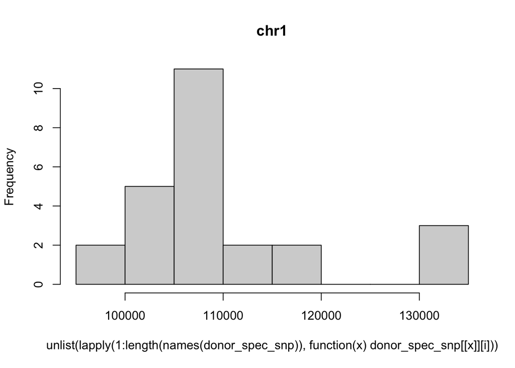

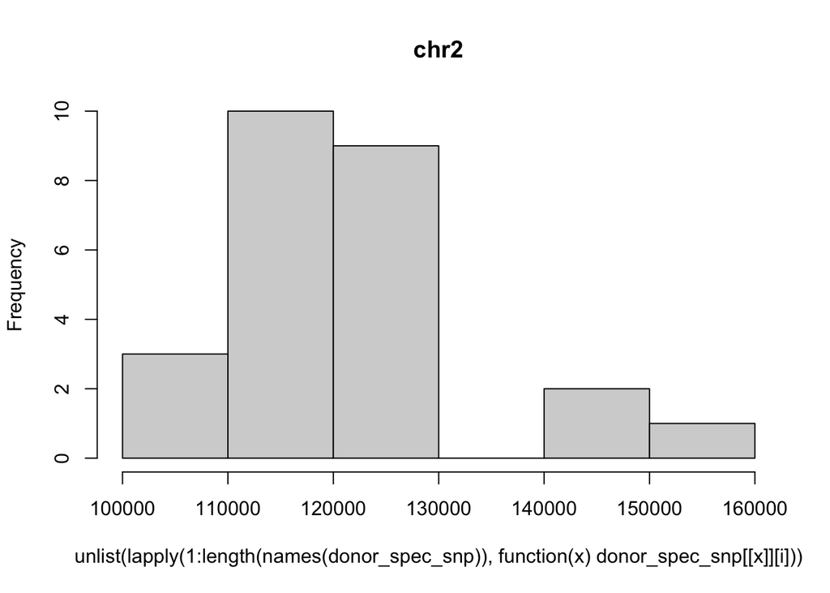

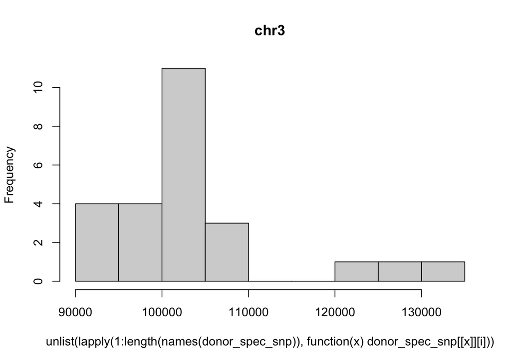

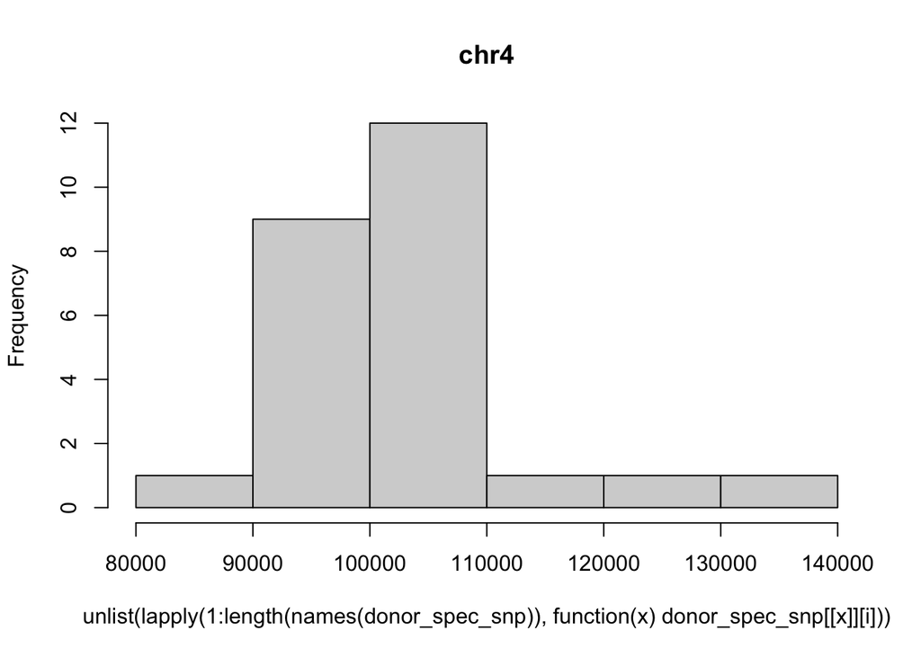

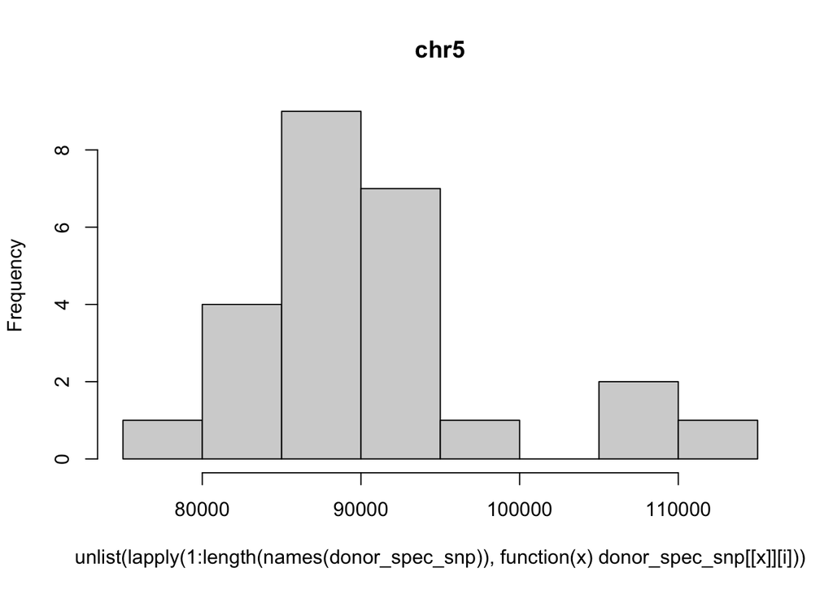

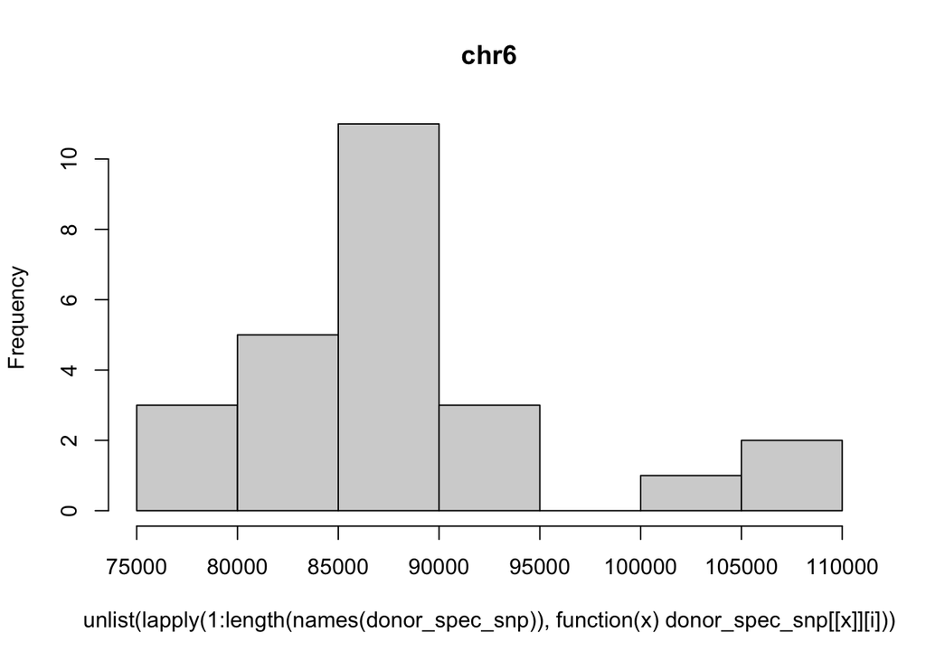

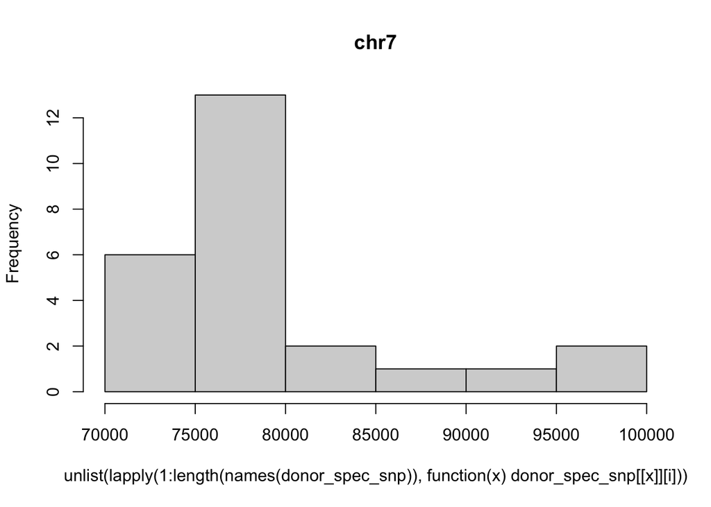

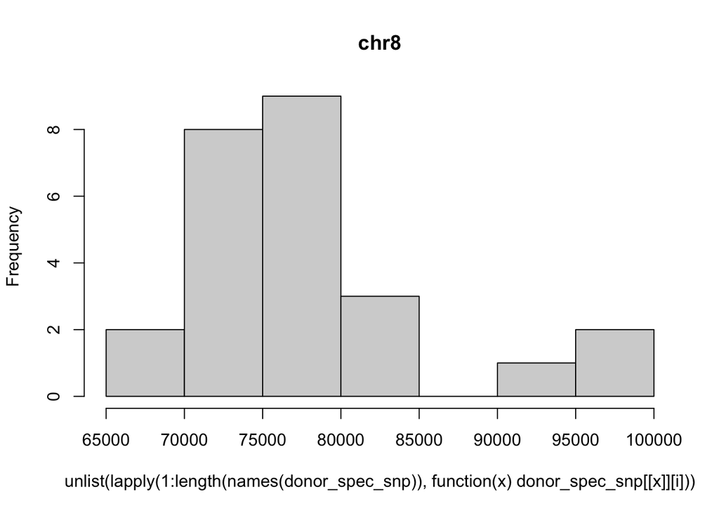

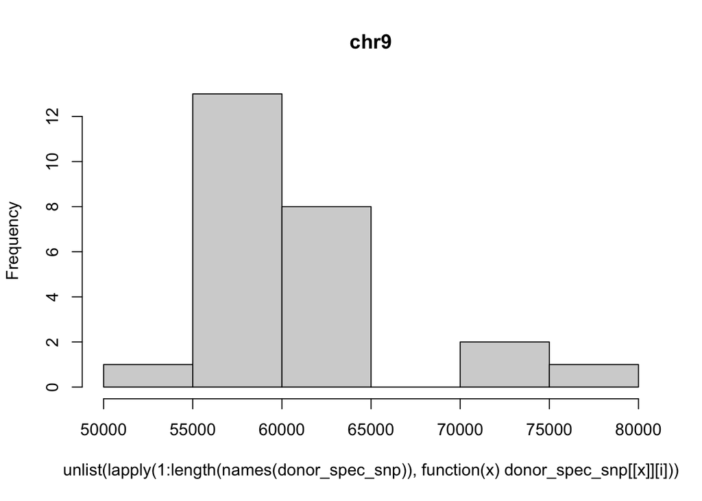

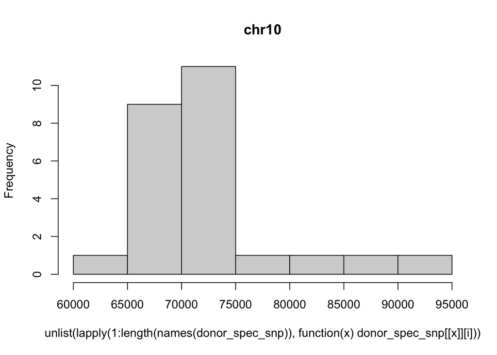

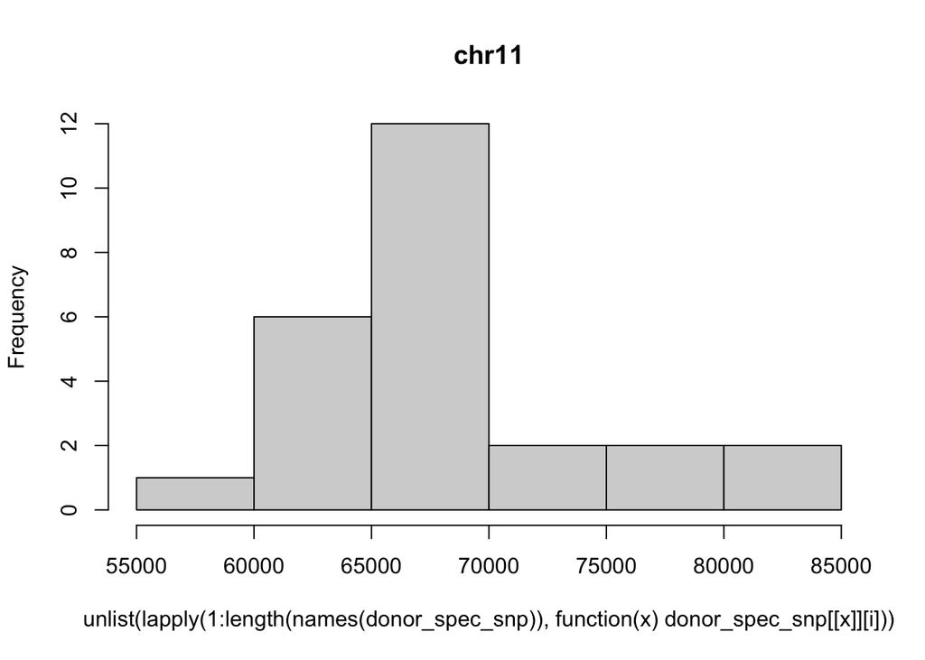

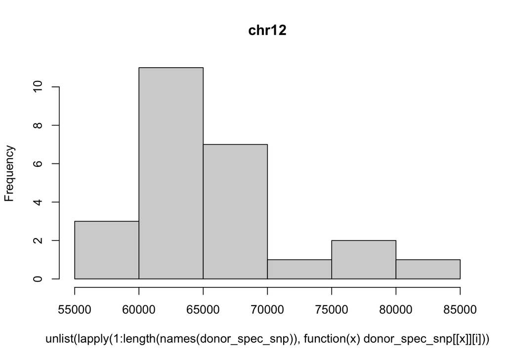

[10 more figures not shown]

```r
for (i in 1:22){
  hist(unlist(lapply(1:length(names(donor_spec_snp)), function(x) donor_spec_snp[[x]][i])), main=paste0("chr", i))

}
```

these are chromosome specific counts of the number of hetSNPs following filtering.

### Infertile Donors

```r
min_inf_snp <- which(inf_df$num_snps == min(inf_df$num_snps))[1]
inf_df[min_inf_snp, c("sample", "chr", "num_snps")]
```

```
##     sample chr num_snps
## 548   pb2a  22    13751
```

```r
max_inf_snp <- which(inf_df$num_snps == max(inf_df$num_snps))[1]
inf_df[max_inf_snp, c("sample", "chr", "num_snps")]
```

```
##    sample chr num_snps
## 49   pb3a   2   120897
```

```r
quant_inf_snp <- quantile(inf_df$num_snps)
quant_inf_snp
```

```
##        0%       25%       50%       75%      100%
##  13751.00  37554.25  58655.00  81415.25 120897.00
```

### Original Cohort of Donors

```r
min_ninf_snp <- which(ninf_df$num_snps == min(ninf_df$num_snps))[1]
ninf_df[min_ninf_snp, c("sample", "chr", "num_snps")]
```

```
##     sample chr num_snps
## 531  nc8ab  22    14450
```

```r
max_ninf_snp <- which(ninf_df$num_snps == max(ninf_df$num_snps))[1]
ninf_df[max_ninf_snp, c("sample", "chr", "num_snps")]
```

```
##      sample chr num_snps
## 43 nc25abcd   2   156043
```

```r
quant_ninf_snp <- quantile(ninf_df$num_snps)
quant_ninf_snp
```

```
##        0%       25%       50%       75%      100%
##  14450.00  38974.50  62550.00  87182.25 156043.00
```

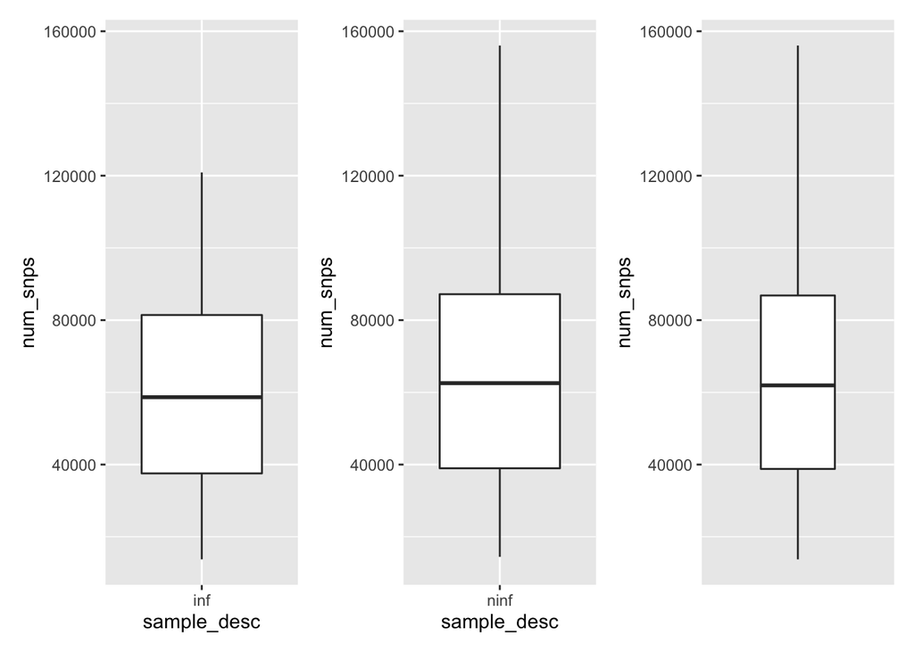

```r
g_inf <- ggplot(inf_df, aes(x = sample_desc, y = num_snps)) + geom_boxplot() + scale_y_continuous(limits=c(min(ninf_df$num_snps[min_ninf_snp], inf_df$num_snps[min_inf_snp]), max(ninf_df$num_snps[max_ninf_snp], inf_df$num_snps[max_inf_snp])))
g_ninf <- ggplot(ninf_df, aes(x = sample_desc, y = num_snps)) + geom_boxplot() + scale_y_continuous(limits=c(min(ninf_df$num_snps[min_ninf_snp], inf_df$num_snps[min_inf_snp]), max(ninf_df$num_snps[max_ninf_snp], inf_df$num_snps[max_inf_snp])))
g_tot <- ggplot(full_df, aes(y = num_snps)) + geom_boxplot() + scale_y_continuous(limits=c(min(ninf_df$num_snps[min_ninf_snp], inf_df$num_snps[min_inf_snp]), max(ninf_df$num_snps[max_ninf_snp], inf_df$num_snps[max_inf_snp]))) + scale_x_discrete(labels=c("both"))

g <- g_inf + g_ninf + g_tot
g
```

In this plot of the number of hetsNPs, after filtering, (donor and chromosome specific), the infertile donors are on the left, the original donor set is in the middle, the combined set is on the left. We seem to have under-estimated the average number of SNPs by using 30K for the simulations. But 30K is near the average for chr17 and chr20 (and is the standard deviation as seen below). And since we do better as we get more data, low-balling this should be no problem at all.

```r
message(paste0("mean infertile donors: ", mean(inf_df$num_snps)))
```

```
## mean infertile donors: 60090.1636363636
```

```r
message(paste0("sd infertile donors: ", sd(inf_df$num_snps)))
```

```
## sd infertile donors: 28758.3158049334
```

```r
message(paste0("mean original donors: ", mean(ninf_df$num_snps)))
```

```
## mean original donors: 64007.5159090909
```

```r
message(paste0("sd original donors: ", sd(ninf_df$num_snps)))
```

```
## sd original donors: 31031.4100456482
```

```r
message(paste0('mean all: ', mean(full_df$num_snps)))
```

```
## mean all: 63224.0454545455
```

```r
message(paste0("sd all: ", sd(full_df$num_snps)))
```

```
## sd all: 30605.0761941311
```

## look at phasing completeness

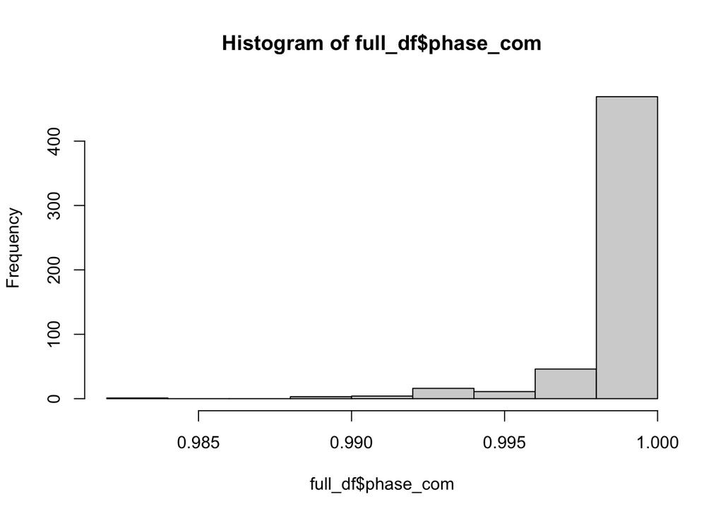

```r
hist(full_df$phase_com)
```

```r
min(full_df$phase_com)
```

```
## [1] 0.9837623
```

```r
max(full_df$phase_com)
```

```
## [1] 1
```

```r
mean(full_df$phase_com)
```

```
## [1] 0.9989478
```

```r
sd(full_df$phase_com)
```

```
## [1] 0.001856551
```

```r
quantile(full_df$phase_com)
```

```
##        0%       25%       50%       75%      100%
## 0.9837623 0.9992080 0.9995752 0.9998072 1.0000000
```

### Infertile donors

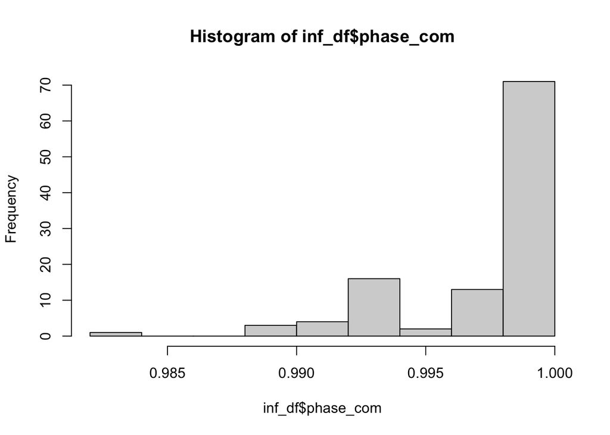

```r
hist(inf_df$phase_com)
```

```r
min(inf_df$phase_com)
```

```
## [1] 0.9837623
```

```r
max(inf_df$phase_com)
```

```
## [1] 1
```

```r
mean(inf_df$phase_com)
```

```
## [1] 0.9976857
```

```r
sd(inf_df$phase_com)
```

```
## [1] 0.003444241
```

```r
quantile(inf_df$phase_com)
```

```
##        0%       25%       50%       75%      100%
## 0.9837623 0.9969388 0.9998653 1.0000000 1.0000000
```

### Original set of donors

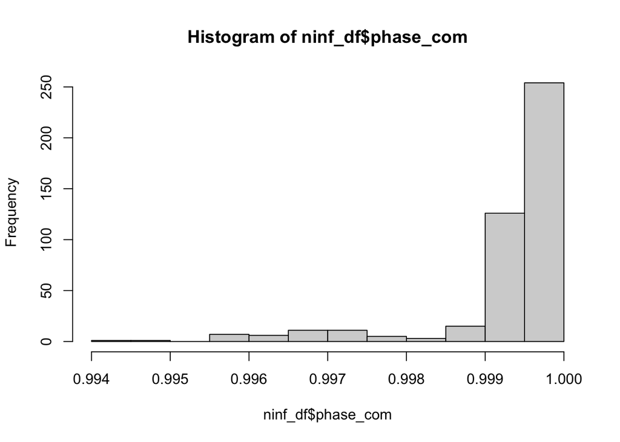

```r
hist(ninf_df$phase_com)
```

```r
min(ninf_df$phase_com)
```

```
## [1] 0.9943269
```

```r
max(ninf_df$phase_com)
```

```
## [1] 1
```

```r
mean(ninf_df$phase_com)
```

```
## [1] 0.9992633
```

```r
sd(ninf_df$phase_com)
```

```
## [1] 0.0009306353
```

```r
quantile(ninf_df$phase_com)
```

```
##        0%       25%       50%       75%      100%
## 0.9943269 0.9992557 0.9995677 0.9997658 1.0000000
```

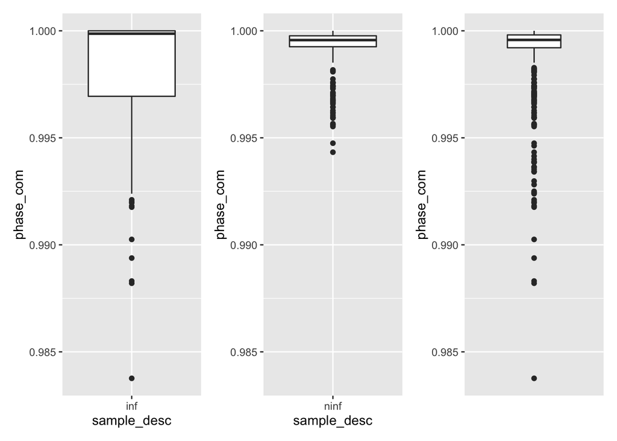

```r
min_inf_pcom <- which(inf_df$phase_com == min(inf_df$phase_com))[1]
min_ninf_pcom <- which(ninf_df$phase_com == min(ninf_df$phase_com))[1]
max_inf_pcom <- which(inf_df$phase_com == max(inf_df$phase_com))[1]
max_ninf_pcom <- which(ninf_df$phase_com == max(ninf_df$phase_com))[1]

g_inf <- ggplot(inf_df, aes(x = sample_desc, y = phase_com)) + geom_boxplot() + scale_y_continuous(limits=c(min(ninf_df$phase_com[min_ninf_pcom], inf_df$phase_com[min_inf_pcom]), max(ninf_df$phase_com[max_ninf_pcom], inf_df$phase_com[max_inf_pcom])))
g_ninf <- ggplot(ninf_df, aes(x = sample_desc, y = phase_com)) + geom_boxplot() + scale_y_continuous(limits=c(min(ninf_df$phase_com[min_ninf_pcom], inf_df$phase_com[min_inf_pcom]), max(ninf_df$phase_com[max_ninf_pcom], inf_df$phase_com[max_inf_pcom])))
g_tot <- ggplot(full_df, aes(y = phase_com)) + geom_boxplot() + scale_y_continuous(limits=c(min(ninf_df$phase_com[min_ninf_pcom], inf_df$phase_com[min_inf_pcom]), max(ninf_df$phase_com[max_ninf_pcom], inf_df$phase_com[max_inf_pcom]))) + scale_x_discrete(labels=c("both"))

g <- g_inf + g_ninf + g_tot
g
```

In this plot of the phasing completeness (donor and chromosome specific), the infertile donors are on the left, the original donor set is in the middle, the combined set is on the left.

```r
message(paste0("mean infertile donors: ", mean(inf_df$phase_com)))
```

```
## mean infertile donors: 0.997685651129779
```

```r
message(paste0("sd infertile donors: ", sd(inf_df$phase_com)))
```

```
## sd infertile donors: 0.00344424081118475
```

```r
message(paste0("mean original donors: ", mean(ninf_df$phase_com)))
```

```
## mean original donors: 0.999263293387455
```

```r
message(paste0("sd original donors: ", sd(ninf_df$phase_com)))
```

```
## sd original donors: 0.000930635302046475
```

```r
message(paste0('mean all: ', mean(full_df$phase_com)))
```

```
## mean all: 0.99894776493592
```

```r
message(paste0("sd all: ", sd(full_df$phase_com)))
```

```
## sd all: 0.00185655080249439
```

Infertile donors appear to have slightly suppressed phasing completeness, but overall comparable to the original donors. The mean for both cohorts together is 99.89 +- 0.19% complete

## look at gamete imputation completeness

```r
undo_str_vec <- function(str_vec){
  undone <- as.numeric(unlist(strsplit(str_vec, '_')))
  return(undone)
}
```

```r
all_imp_com <- unlist(lapply(1:nrow(full_df), function(x) undo_str_vec(full_df$imp_com[x])))
inf_imp_com <- unlist(lapply(1:nrow(inf_df), function(x) undo_str_vec(inf_df$imp_com[x])))
ninf_imp_com <- unlist(lapply(1:nrow(ninf_df), function(x) undo_str_vec(ninf_df$imp_com[x])))
```

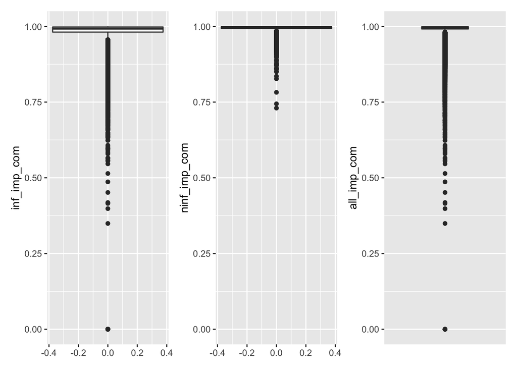

```r
min_inf_icom <- which(inf_imp_com == min(inf_imp_com))[1]
min_ninf_icom <- which(ninf_imp_com == min(ninf_imp_com))[1]
max_inf_icom <- which(inf_imp_com == max(inf_imp_com))[1]
max_ninf_icom <- which(ninf_imp_com == max(ninf_imp_com))[1]

g_inf <- ggplot(as.data.table(inf_imp_com), aes(y=inf_imp_com)) + geom_boxplot() + scale_y_continuous(limits=c(min(ninf_imp_com[min_ninf_icom], inf_imp_com[min_inf_icom]), max(ninf_imp_com[max_ninf_icom], inf_imp_com[max_inf_icom])))
g_ninf <- ggplot(as.data.table(ninf_imp_com), aes(y=ninf_imp_com)) + geom_boxplot() + scale_y_continuous(limits=c(min(ninf_imp_com[min_ninf_icom], inf_imp_com[min_inf_icom]), max(ninf_imp_com[max_ninf_icom], inf_imp_com[max_inf_icom])))
g_tot <- ggplot(as.data.table(all_imp_com), aes(y=all_imp_com)) + geom_boxplot() + scale_y_continuous(limits=c(min(ninf_imp_com[min_ninf_icom], inf_imp_com[min_inf_icom]), max(ninf_imp_com[max_ninf_icom], inf_imp_com[max_inf_icom]))) + scale_x_discrete(labels=c("both"))

g <- g_inf + g_ninf + g_tot
g
```

In this plot of the gamete imputation completeness (donor, chromosome, and gamete specific), the infertile donors are on the left, the original donor set is in the middle, the combined set is on the left. Note that the min for the infertile donors is 0% completeness, compared to about 73% for the original donor set. Thankfully, this is a major outlier as the 25th percentile is around 98% (as seen below).

```r
message(paste0("mean infertile donors: ", mean(inf_imp_com)))
```

```
## mean infertile donors: 0.984493441292405
```

```r
message(paste0("sd infertile donors: ", sd(inf_imp_com)))
```

```
## sd infertile donors: 0.0252344306971294
```

```r
message(paste0("mean original donors: ", mean(ninf_imp_com)))
```

```
## mean original donors: 0.994895770267944
```

```r
message(paste0("sd original donors: ", sd(ninf_imp_com)))
```

```
## sd original donors: 0.00563185767020054
```

```r
message(paste0('mean all: ', mean(all_imp_com)))
```

```
## mean all: 0.992081468797671
```

```r
message(paste0("sd all: ", sd(all_imp_com)))
```

```
## sd all: 0.0147230476642437
```

### Original set of donors

```r
min(ninf_imp_com)
```

```
## [1] 0.7301333
```

```r
max(ninf_imp_com)
```

```
## [1] 1
```

```r
mean(ninf_imp_com)
```

```
## [1] 0.9948958
```

```r
sd(ninf_imp_com)
```

```
## [1] 0.005631858
```

```r
quantile(ninf_imp_com)
```

```
##        0%       25%       50%       75%      100%
## 0.7301333 0.9929673 0.9964488 0.9989216 1.0000000
```

### Infertile donors

```r
min(inf_imp_com)
```

```
## [1] 0
```

```r
max(inf_imp_com)
```

```
## [1] 1
```

```r
mean(inf_imp_com)
```

```
## [1] 0.9844934
```

```r
sd(inf_imp_com)
```

```
## [1] 0.02523443
```

```r
quantile(inf_imp_com)
```

```
##        0%       25%       50%       75%      100%
## 0.0000000 0.9811093 0.9928138 0.9981267 1.0000000
```

## breakpoint resolution (in base pairs for real this time!)

```r
all_res <- unlist(lapply(1:nrow(full_df), function(x) undo_str_vec(full_df$res[x])))
inf_res <- unlist(lapply(1:nrow(inf_df), function(x) undo_str_vec(inf_df$res[x])))
ninf_res <- unlist(lapply(1:nrow(ninf_df), function(x) undo_str_vec(ninf_df$res[x])))
```

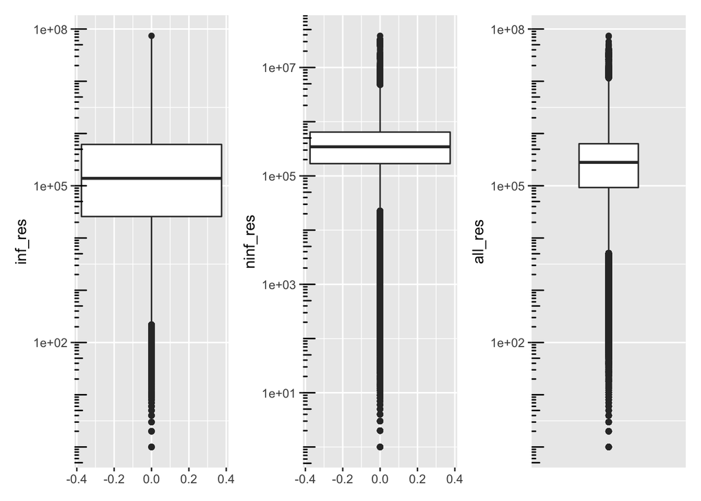

```r
min_inf_res <- which(inf_res == min(inf_res))[1]
min_ninf_res <- which(ninf_res == min(ninf_res))[1]
max_inf_res <- which(inf_res == max(inf_res))[1]
max_ninf_res <- which(ninf_res == max(ninf_res))[1]

g_inf <- ggplot(as.data.table(inf_res), aes(y=inf_res)) + geom_boxplot() + scale_y_log10() + annotation_logticks(scaled=TRUE, sides='l')
g_ninf <- ggplot(as.data.table(ninf_res), aes(y=ninf_res)) + geom_boxplot() + scale_y_log10() + annotation_logticks(scaled=TRUE, sides='l')
g_tot <- ggplot(as.data.table(all_res), aes(y=all_res)) + geom_boxplot() + scale_x_discrete(labels=c("both")) + scale_y_log10() + annotation_logticks(scaled=TRUE, sides='l')

g <- g_inf + g_ninf + g_tot
g
```

In this plot of the predicted meiotic breakpoint resolution (donor, chromosome, and gamete specific), the infertile donors are on the left, the original donor set is in the middle, the combined set is on the left. Note that the breakpoint resolution is actual base pairs this time!

```r
message(paste0("mean infertile donors: ", mean(inf_res)))
```

```
## mean infertile donors: 681981.29779972
```

```r
message(paste0("sd infertile donors: ", sd(inf_res)))
```

```
## sd infertile donors: 1632818.47693665
```

```r
message(paste0("mean original donors: ", mean(ninf_res)))
```

```
## mean original donors: 525489.221135424
```

```r
message(paste0("sd original donors: ", sd(ninf_res)))
```

```
## sd original donors: 891172.565087
```

```r
message(paste0('mean all: ', mean(all_res)))
```

```
## mean all: 589046.205488826
```

```r
message(paste0("sd all: ", sd(all_res)))
```

```
## sd all: 1249136.47041477
```

### Original set of donors

```r
min(ninf_res)
```

```
## [1] 1
```

```r
max(ninf_res)
```

```
## [1] 38379432
```

```r
mean(ninf_res)
```

```
## [1] 525489.2
```

```r
sd(ninf_res)
```

```
## [1] 891172.6
```

```r
quantile(ninf_res)
```

```
##         0%        25%        50%        75%       100%
##        1.0   168386.8   344533.5   643101.0 38379432.0
```

### Infertile donors

```r
min(inf_res)
```

```
## [1] 1
```

```r
max(inf_res)
```

```
## [1] 74158225
```

```r
mean(inf_res)
```

```
## [1] 681981.3
```

```r
sd(inf_res)
```

```
## [1] 1632818
```

```r
quantile(inf_res)
```

```
##       0%      25%      50%      75%     100%
##        1    25767   138748   617862 74158225
```

## completeness of input data

```r
all_input_com <- unlist(lapply(1:nrow(full_df), function(x) undo_str_vec(full_df$input_com[x])))
inf_input_com <- unlist(lapply(1:nrow(inf_df), function(x) undo_str_vec(inf_df$input_com[x])))
ninf_input_com <- unlist(lapply(1:nrow(ninf_df), function(x) undo_str_vec(ninf_df$input_com[x])))
```

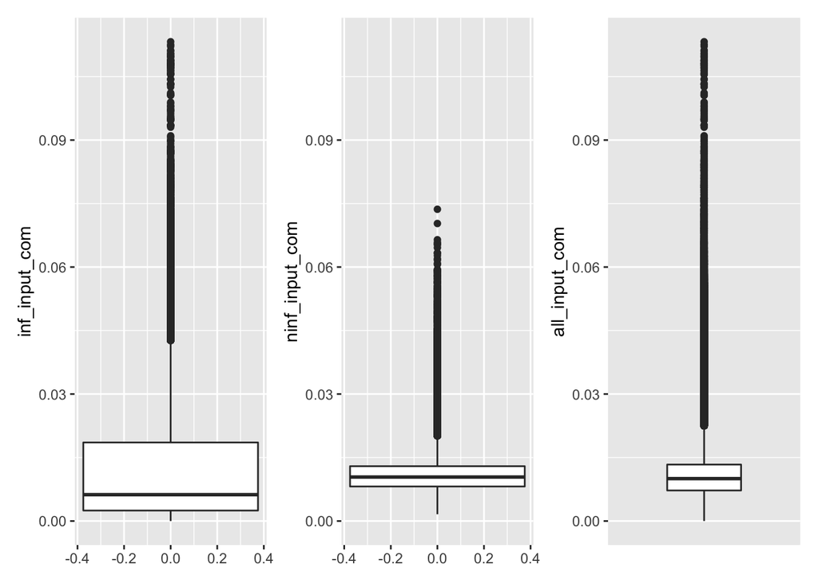

```r
min_inf_inpcom <- which(inf_input_com == min(inf_input_com))[1]
min_ninf_inpcom <- which(ninf_input_com == min(ninf_input_com))[1]
max_inf_inpcom <- which(inf_input_com == max(inf_input_com))[1]
max_ninf_inpcom <- which(ninf_input_com == max(ninf_input_com))[1]

g_inf <- ggplot(as.data.table(inf_input_com), aes(y=inf_input_com)) + geom_boxplot() + scale_y_continuous(limits=c(min(ninf_input_com[min_ninf_inpcom], inf_input_com[min_inf_inpcom]), max(ninf_input_com[max_ninf_inpcom], inf_input_com[max_inf_inpcom])))
g_ninf <- ggplot(as.data.table(ninf_input_com), aes(y=ninf_input_com)) + geom_boxplot() + scale_y_continuous(limits=c(min(ninf_input_com[min_ninf_inpcom], inf_input_com[min_inf_inpcom]), max(ninf_input_com[max_ninf_inpcom], inf_input_com[max_inf_inpcom])))
g_tot <- ggplot(as.data.table(all_input_com), aes(y=all_input_com)) + geom_boxplot() + scale_y_continuous(limits=c(min(ninf_input_com[min_ninf_inpcom], inf_input_com[min_inf_inpcom]), max(ninf_input_com[max_ninf_inpcom], inf_input_com[max_inf_inpcom]))) + scale_x_discrete(labels=c("both"))

g <- g_inf + g_ninf + g_tot
g
```

In this plot of the input completeness (donor, chromosome, and gamete specific), the infertile donors are on the left, the original donor set is in the middle, the combined set is on the left. Note that the max for the infertile donors is >9% completeness, compared to about 7.5% for the original donor set.

```r
message(paste0("mean infertile donors: ", mean(inf_input_com)))
```

```
## mean infertile donors: 0.0125899577231895
```

```r
message(paste0("sd infertile donors: ", sd(inf_input_com)))
```

```
## sd infertile donors: 0.0137877513816203
```

```r
message(paste0("mean original donors: ", mean(ninf_input_com)))
```

```
## mean original donors: 0.0109367623112843
```

```r
message(paste0("sd original donors: ", sd(ninf_input_com)))
```

```
## sd original donors: 0.0039034538230503
```

```r
message(paste0('mean all: ', mean(all_input_com)))
```

```
## mean all: 0.0113840266007828
```

```r
message(paste0("sd all: ", sd(all_input_com)))
```

```
## sd all: 0.00794261390235215
```

### Original set of donors

```r
min(ninf_input_com)
```

```
## [1] 0.00160222
```

```r
max(ninf_input_com)
```

```
## [1] 0.07364775
```

```r
mean(ninf_input_com)
```

```
## [1] 0.01093676
```

```r
sd(ninf_input_com)
```

```
## [1] 0.003903454
```

```r
quantile(ninf_input_com)
```

```
##          0%         25%         50%         75%        100%
## 0.001602220 0.008160725 0.010391712 0.012956522 0.073647754
```

### Infertile donors

```r
min(inf_input_com)
```

```
## [1] 0
```

```r
max(inf_input_com)
```

```
## [1] 0.1132229
```

```r
mean(inf_input_com)
```

```
## [1] 0.01258996
```

```r
sd(inf_input_com)
```

```
## [1] 0.01378775
```

```r
quantile(inf_input_com)
```

```
##          0%         25%         50%         75%        100%
## 0.000000000 0.002485154 0.006229436 0.018559119 0.113222933
```

### Completeness to coverage

for this next group of EDA, we’ll translate to the missing genotype rate (MGR) and then translate missing genotype rate to coverage. I assume that MGR is the opposite of completeness or the # of NAs / number of SNPs (as opposed to the number of non-NAs / number of SNPs which is completeness). So this is just subtracting the completeness from 1. we then translate it to coverage by taking the -log.

```r
all_input_cov <- unlist(lapply(1:nrow(full_df), function(x) -log(1-undo_str_vec(full_df$input_com[x]))))
inf_input_cov <- unlist(lapply(1:nrow(inf_df), function(x) -log(1-undo_str_vec(inf_df$input_com[x]))))
ninf_input_cov <- unlist(lapply(1:nrow(ninf_df), function(x) -log(1-undo_str_vec(ninf_df$input_com[x]))))
```

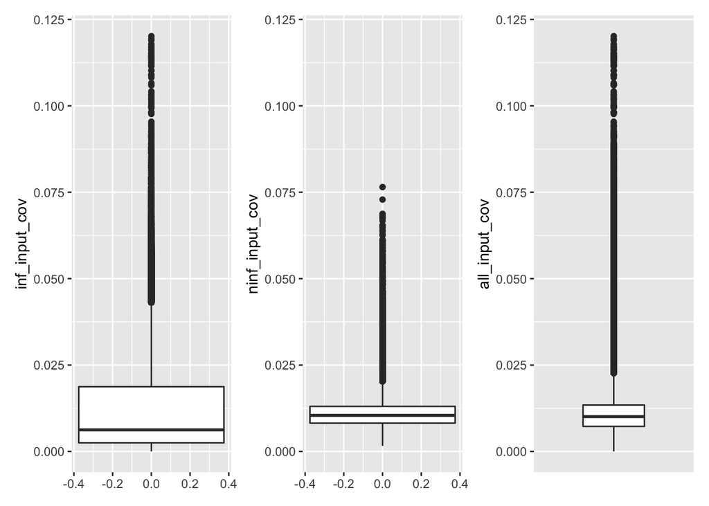

```r
min_inf_inpcov <- which(inf_input_cov == min(inf_input_cov))[1]
min_ninf_inpcov <- which(ninf_input_cov == min(ninf_input_cov))[1]
max_inf_inpcov <- which(inf_input_cov == max(inf_input_cov))[1]
max_ninf_inpcov <- which(ninf_input_cov == max(ninf_input_cov))[1]

g_inf <- ggplot(as.data.table(inf_input_cov), aes(y=inf_input_cov)) + geom_boxplot() + scale_y_continuous(limits=c(min(ninf_input_cov[min_ninf_inpcov], inf_input_cov[min_inf_inpcov]), max(ninf_input_cov[max_ninf_inpcov], inf_input_cov[max_inf_inpcov])))
g_ninf <- ggplot(as.data.table(ninf_input_cov), aes(y=ninf_input_cov)) + geom_boxplot() + scale_y_continuous(limits=c(min(ninf_input_cov[min_ninf_inpcov], inf_input_cov[min_inf_inpcov]), max(ninf_input_cov[max_ninf_inpcov], inf_input_cov[max_inf_inpcov])))
g_tot <- ggplot(as.data.table(all_input_cov), aes(y=all_input_cov)) + geom_boxplot() + scale_y_continuous(limits=c(min(ninf_input_cov[min_ninf_inpcov], inf_input_cov[min_inf_inpcov]), max(ninf_input_cov[max_ninf_inpcov], inf_input_cov[max_inf_inpcov])))  + scale_x_discrete(labels=c("both"))

g <- g_inf + g_ninf + g_tot
g
```

In this plot of the input approximate coverage (donor, chromosome, and gamete specific), the infertile donors are on the left, the original donor set is in the middle, the combined set is on the left.

```r
message(paste0("mean infertile donors: ", mean(inf_input_cov)))
```

```
## mean infertile donors: 0.012768770888996
```

```r
message(paste0("sd infertile donors: ", sd(inf_input_cov)))
```

```
## sd infertile donors: 0.0141137318356838
```

```r
message(paste0("mean original donors: ", mean(ninf_input_cov)))
```

```
## mean original donors: 0.0110048316029012
```

```r
message(paste0("sd original donors: ", sd(ninf_input_cov)))
```

```
## sd original donors: 0.00396008182515815
```

```r
message(paste0('mean all: ', mean(all_input_cov)))
```

```
## mean all: 0.0114820571298003
```

```r
message(paste0("sd all: ", sd(all_input_cov)))
```

```
## sd all: 0.00812067213491068
```

### Original set of donors

```r
min(ninf_input_cov)
```

```
## [1] 0.001603505
```

```r
max(ninf_input_cov)
```

```
## [1] 0.07650072
```

```r
mean(ninf_input_cov)
```

```
## [1] 0.01100483
```

```r
sd(ninf_input_cov)
```

```
## [1] 0.003960082
```

```r
quantile(ninf_input_cov)
```

```
##          0%         25%         50%         75%        100%
## 0.001603505 0.008194206 0.010446083 0.013041190 0.076500721
```

### Infertile donors

```r
min(inf_input_cov)
```

```
## [1] 0
```

```r
max(inf_input_cov)
```

```
## [1] 0.1201617
```

```r
mean(inf_input_cov)
```

```
## [1] 0.01276877
```

```r
sd(inf_input_cov)
```

```
## [1] 0.01411373
```

```r
quantile(inf_input_cov)
```

```
##          0%         25%         50%         75%        100%
## 0.000000000 0.002488247 0.006248920 0.018733501 0.120161662
```